# Dissertation Participant 1

## Demographic Information

Participant Demographics

| Sex | Age | Prior Concussions | History of Depression or Anxiety |
| --- | --- | --- | --- |
| Female | 16 | 0 | No |

## Outcome Measurements

During the final session when discussing final outcome measurements (specifically the BRIEF, CLASS, and PCSS), the participant believed the general, negative trend in her responses across the three time points of collection was due to the demands of school. The participant enrolled in the study at the beginning of her school year where she believed her concussion was not severely impacting her academic performance. As the school year progressed in tandem with the study, she believed the increase in her academic demands was exacerbated by her concussion (e.g. much more time looking at a screen compared to the summer).

The participant also reported that increased awareness to her perceived deficits influenced her responses on the post-treatment outcome measurements.

### GAS Hierarchy - Number of minutes per class engaged in online Literature lecture (60 minute class)

| Level | Outcome |
| --- | --- |
| Much more than expected | 36 to 45 minutes |
| More than expected | 26 to 35 minutes |
| Expected | 16 to 25 minutes |
| Baseline | 6 to 15 minutes |
| Decline | 0 to 5 minutes |

### BRIEF-2

Self-report responses that guided treatment at time of pre-baseline data collection:

- Self-Monitor Scale
- Task Completion Scale
- Plan/Organize Scale
- Cognitive Regulation Index

There were no scores in the clinically significant range on the pre-baseline parent-response. The highest score was the Working Memory scale, with a *T*-score of 62. The Working Memory scale increased to a clinically significant *T*-score of 67 on the post-treatment parent-response. Also, the Organization of Materials scale was observed to be clinically significant on the post-treatment parent-response (*T*-score = 67). Overall, the parent-response total scores remained relatively similar. Decreases in the BRI and ERI from pre-treatment to post-treatment were observed, while the CRI was observed to increase from pre- to post-treatment.

Across the board, most self-report scale/index scores remained elevated or even increased, which may demonstrate increased self-awareness or increased self-perception of challenges.

#### BRIEF-2 Self-Report

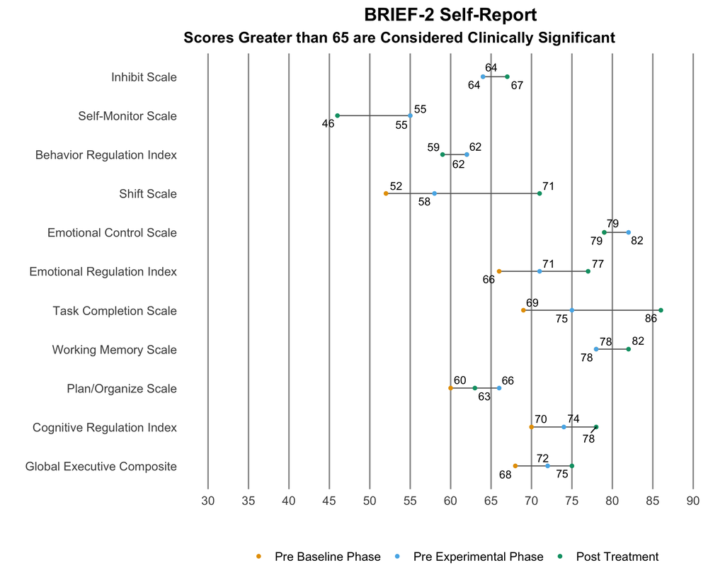

#### BRIEF-2 Self-Report Table Version 1

| Scale/Index | Pre Baseline Phase | Pre Experimental Phase | Post Treatment |
| --- | --- | --- | --- |
| Inhibit Scale | 64 | 64 | 67 |
| Self-Monitor Scale | 55 | 55 | 46 |
| Behavior Regulation Index | 62 | 62 | 59 |
| Shift Scale | 52 | 58 | 71 |
| Emotional Control Scale | 79 | 82 | 79 |
| Emotional Regulation Index | 66 | 71 | 77 |
| Task Completion Scale | 69 | 75 | 86 |
| Working Memory Scale | 78 | 78 | 82 |
| Plan/Organize Scale | 60 | 66 | 63 |
| Cognitive Regulation Index | 70 | 74 | 78 |

[output cut: 1 more lines]

#### BRIEF-2 Self-Report Table Version 2

| Scale/Index | Pre Baseline Phase | Pre Experimental Phase | Post Treatment |
| --- | --- | --- | --- |
| Inhibit Scale | 64 | 64 | 67 |
| Self-Monitor Scale | 55 | 55 | 46 |
| Behavior Regulation Index | 62 | 62 | 59 |
| Shift Scale | 52 | 58 | 71 |
| Emotional Control Scale | 79 | 82 | 79 |
| Emotional Regulation Index | 66 | 71 | 77 |
| Task Completion Scale | 69 | 75 | 86 |
| Working Memory Scale | 78 | 78 | 82 |
| Plan/Organize Scale | 60 | 66 | 63 |
| Cognitive Regulation Index | 70 | 74 | 78 |

[output cut: 1 more lines]

#### BRIEF-2 Parent-Report

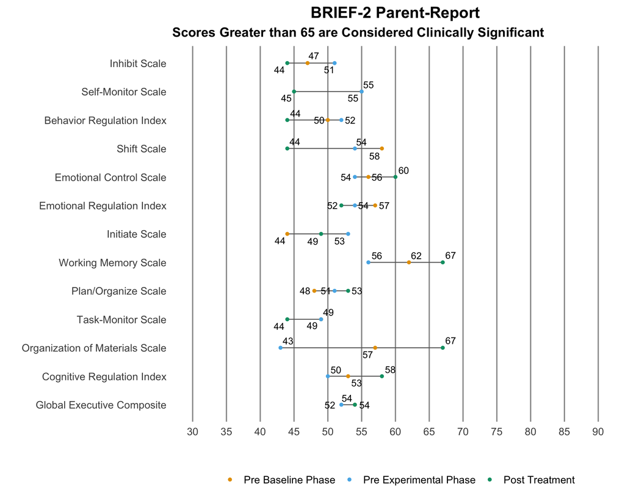

#### BRIEF-2 Parent-Report Version 1

| Scale/Index | Pre Baseline Phase | Pre Experimental Phase | Post Treatment |
| --- | --- | --- | --- |
| Inhibit Scale | 47 | 51 | 44 |
| Self-Monitor Scale | 55 | 55 | 45 |
| Behavior Regulation Index | 50 | 52 | 44 |
| Shift Scale | 58 | 54 | 44 |
| Emotional Control Scale | 56 | 54 | 60 |
| Emotional Regulation Index | 57 | 54 | 52 |
| Initiate Scale | 44 | 53 | 49 |
| Working Memory Scale | 62 | 56 | 67 |
| Plan/Organize Scale | 48 | 51 | 53 |
| Task-Monitor Scale | 49 | 49 | 44 |

[output cut: 3 more lines]

#### BRIEF-2 Parent-Report Table Version 2

| Scale/Index | Pre Baseline Phase | Pre Experimental Phase | Post Treatment |
| --- | --- | --- | --- |
| Inhibit Scale | 47 | 51 | 44 |
| Self-Monitor Scale | 55 | 55 | 45 |
| Behavior Regulation Index | 50 | 52 | 44 |
| Shift Scale | 58 | 54 | 44 |
| Emotional Control Scale | 56 | 54 | 60 |
| Emotional Regulation Index | 57 | 54 | 52 |
| Initiate Scale | 44 | 53 | 49 |
| Working Memory Scale | 62 | 56 | 67 |
| Plan/Organize Scale | 48 | 51 | 53 |
| Task-Monitor Scale | 49 | 49 | 44 |

[output cut: 3 more lines]

### CLASS

Self-report responses that guided treatment at time of pre-baseline data collection:

- Difficulty understanding new material
- Trouble remembering what was studied

Parent-report responses that guided treatment at time of pre-baseline data collection:

- Difficulty understanding new material
- Trouble remembering what was studied

#### CLASS Self 1

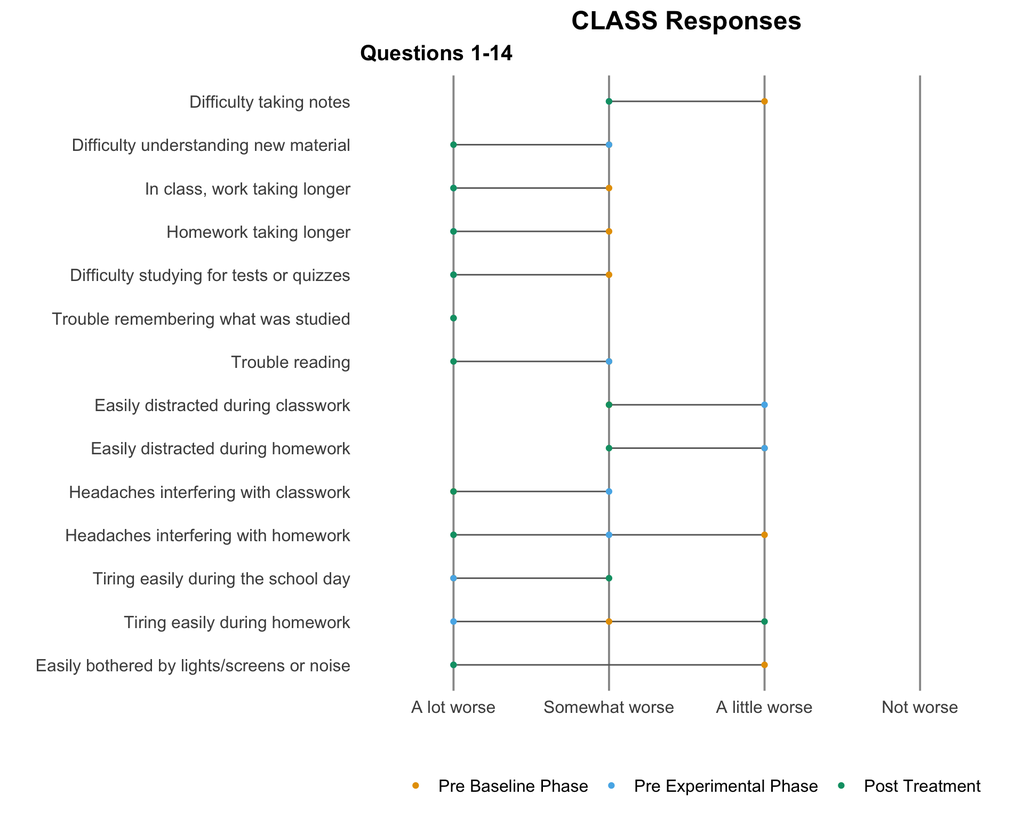

#### CLASS Self 2

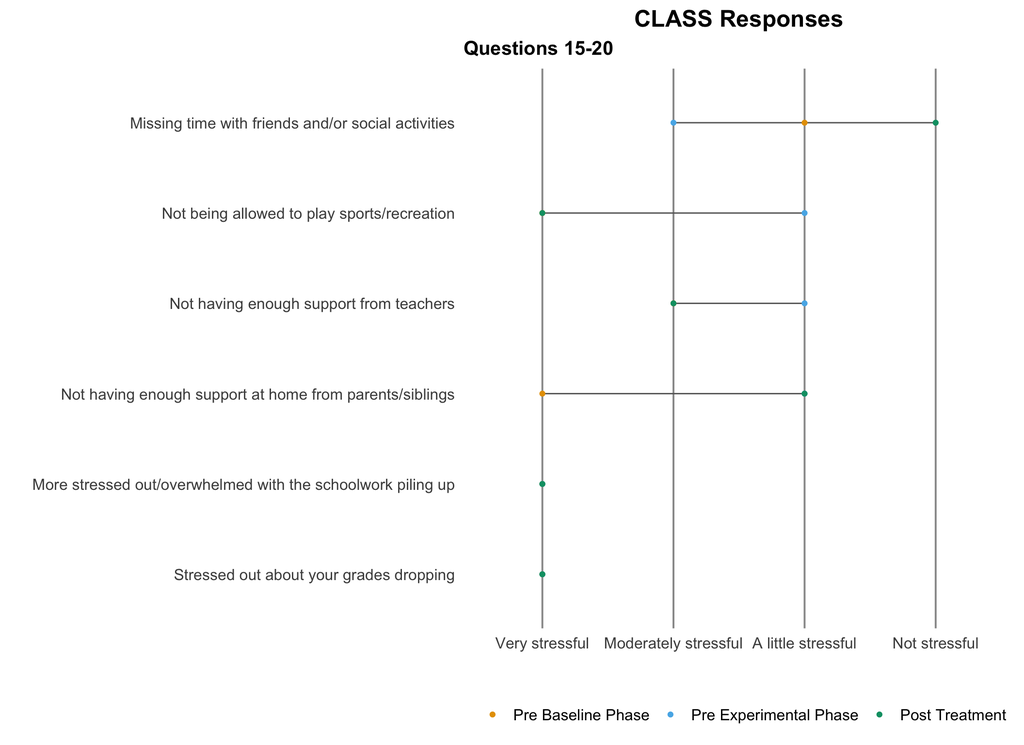

#### CLASS Self Table

| Question | Pre Baseline Phase | Pre Experimental Phase | Post Treatment |
| --- | --- | --- | --- |
| Difficulty taking notes | A little worse | Somewhat worse | Somewhat worse |
| Difficulty understanding new material | Somewhat worse | Somewhat worse | A lot worse |
| In class, work taking longer | Somewhat worse | A lot worse | A lot worse |
| Homework taking longer | Somewhat worse | A lot worse | A lot worse |
| Difficulty studying for tests or quizzes | Somewhat worse | A lot worse | A lot worse |
| Trouble remembering what was studied | A lot worse | A lot worse | A lot worse |
| Trouble reading | Somewhat worse | Somewhat worse | A lot worse |
| Easily distracted during classwork | Somewhat worse | A little worse | Somewhat worse |
| Easily distracted during homework | A little worse | A little worse | Somewhat worse |
| Headaches interfering with classwork | A lot worse | Somewhat worse | A lot worse |

[output cut: 10 more lines]

#### CLASS Parent 1

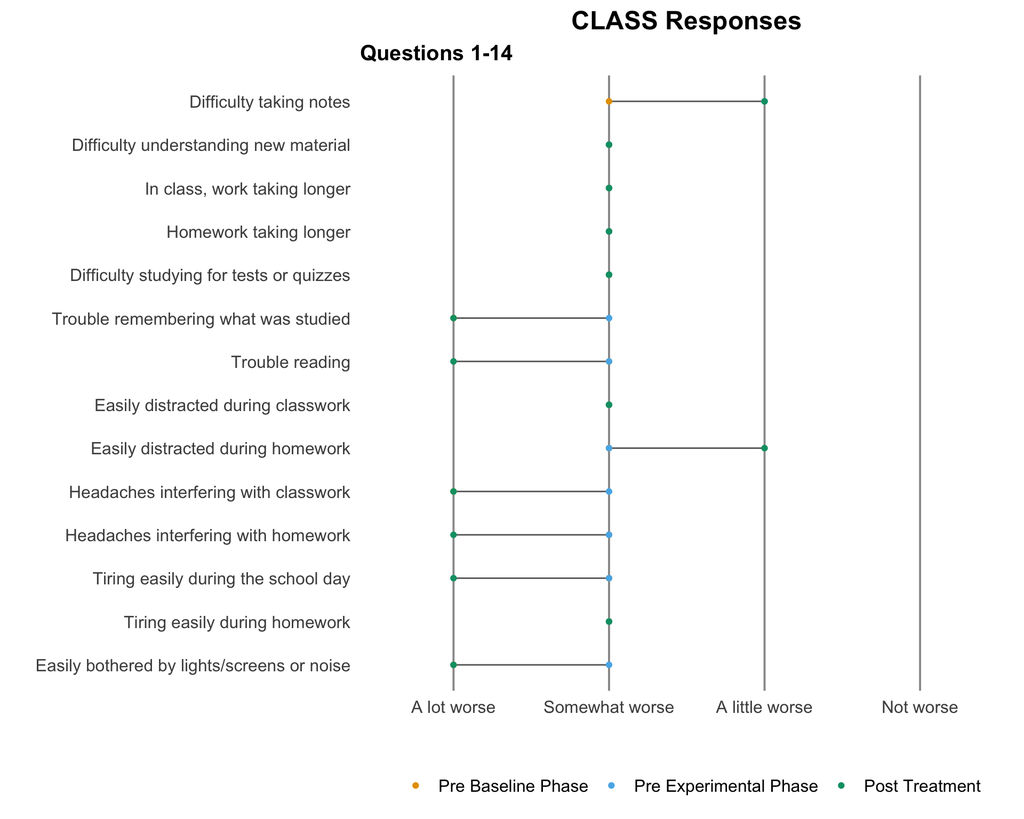

#### CLASS parent 2

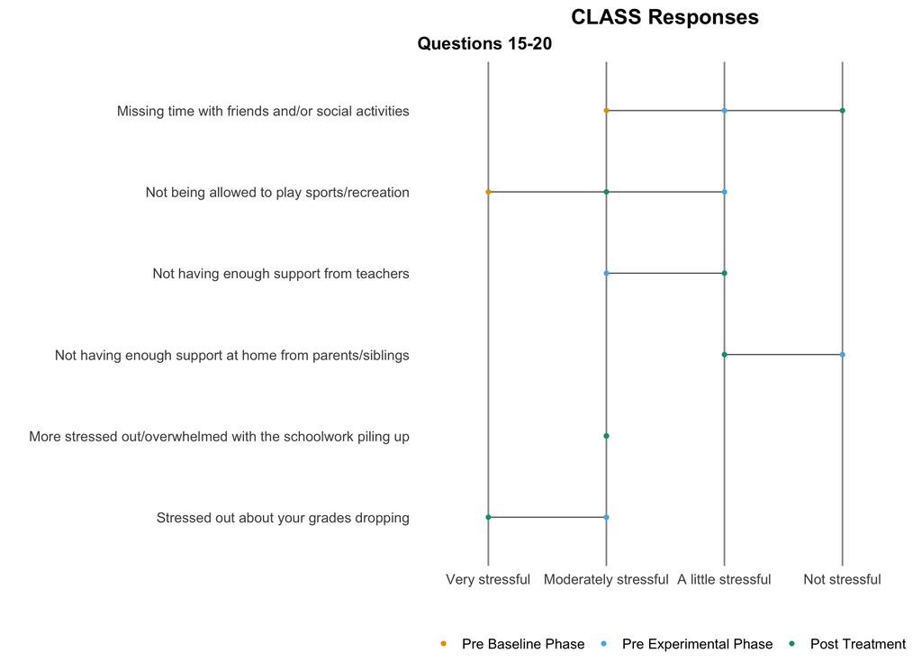

#### ClASS Parent Table

| Question | Pre Baseline Phase | Pre Experimental Phase | Post Treatment |
| --- | --- | --- | --- |
| Difficulty taking notes | Somewhat worse | A little worse | A little worse |
| Difficulty understanding new material | Somewhat worse | Somewhat worse | Somewhat worse |
| In class, work taking longer | Somewhat worse | Somewhat worse | Somewhat worse |
| Homework taking longer | Somewhat worse | Somewhat worse | Somewhat worse |
| Difficulty studying for tests or quizzes | Somewhat worse | Somewhat worse | Somewhat worse |
| Trouble remembering what was studied | A lot worse | Somewhat worse | A lot worse |
| Trouble reading | Somewhat worse | Somewhat worse | A lot worse |
| Easily distracted during classwork | Somewhat worse | Somewhat worse | Somewhat worse |
| Easily distracted during homework | Somewhat worse | Somewhat worse | A little worse |
| Headaches interfering with classwork | A lot worse | Somewhat worse | A lot worse |

[output cut: 10 more lines]

### PCSS

Pre-baseline symptom severity levels that guided treatment selection:

- Difficulty concentrating
- Feeling “slow”
- Feeling “foggy”
- Cognitive symptom cluster

#### All Scores

| Symptom | Pre Baseline Phase | Pre Experimental Phase | Post Treatment |
| --- | --- | --- | --- |
| Headache | 2 | 2 | 4 |
| Nausea | 4 | 4 | 4 |
| Vomiting | 0 | 3 | 2 |
| Balance problems | 4 | 4 | 5 |
| Dizziness | 1 | 2 | 3 |
| Fatigue | 4 | 5 | 4 |
| Trouble falling asleep | 6 | 3 | 2 |
| Excessive sleep | 4 | 4 | 4 |
| Loss of sleep | 1 | 1 | 2 |
| Drowsiness | 3 | 3 | 2 |

[output cut: 19 more lines]

#### Symptom Scores

| Symptom | Pre Baseline Phase | Pre Experimental Phase | Post Treatment |
| --- | --- | --- | --- |
| Headache | 2 | 2 | 4 |
| Nausea | 4 | 4 | 4 |
| Vomiting | 0 | 3 | 2 |
| Balance problems | 4 | 4 | 5 |
| Dizziness | 1 | 2 | 3 |
| Fatigue | 4 | 5 | 4 |
| Trouble falling asleep | 6 | 3 | 2 |
| Excessive sleep | 4 | 4 | 4 |
| Loss of sleep | 1 | 1 | 2 |
| Drowsiness | 3 | 3 | 2 |

[output cut: 12 more lines]

#### Total and Cluster Scores

| Symptom | Pre Baseline Phase | Pre Experimental Phase | Post Treatment |
| --- | --- | --- | --- |
| Total Score | 71 | 76 | 77 |
| Headache-Migraine Cluster | 12 | 10 | 12 |
| Cognitive Cluster | 16 | 19 | 20 |
| Anxiety-Mood Cluster | 16 | 16 | 15 |
| Ocular-Motor Cluster | 0 | 2 | 2 |
| Vestibular Cluster | 9 | 13 | 14 |
| Sleep Cluster | 18 | 16 | 14 |

## Repeated Measurements

### Status Tracking Measurement

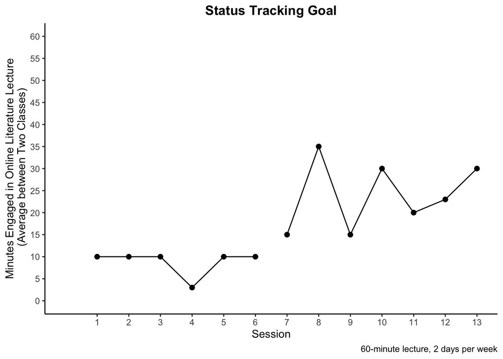

### Repeated Strategy Measurements

Cognitive Strategy: Engage in online lecture for 15 minutes removed from distractions, take a 5-minute break, and rejoin online lecture for at least 15 more minutes.

Cognitive Strategy 2: Set reminders in phone to remember to take a break during lecture (developed during session 10 to be measured sessions 11-13). Participant will adhere to the two set reminders per week.

- Discussion to add additional reminders to best utilize strategy to re-engage in lecture (6 reminders per class lecture) occurred during session 12. Strategy adjusted to adhere to the 12 set reminders per week.

#### Frequency of Use of Break Strategy

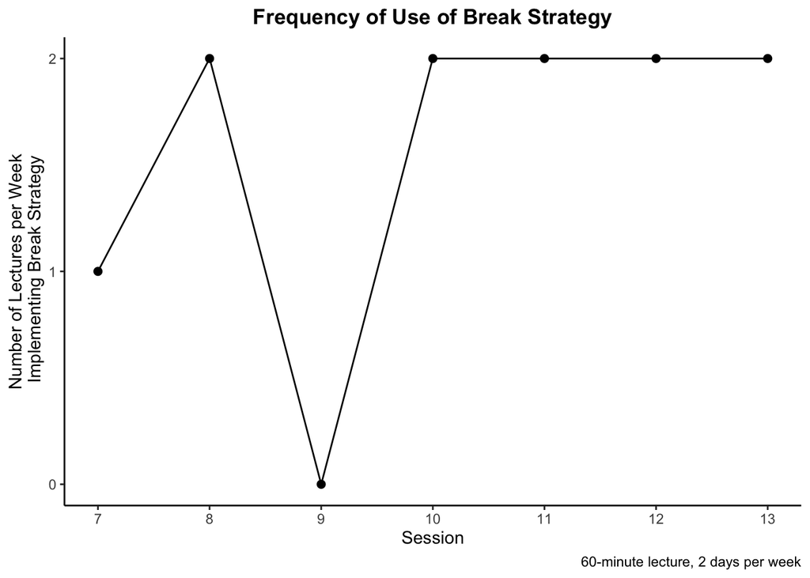

#### Perceived Helpfulness of Break Strategy

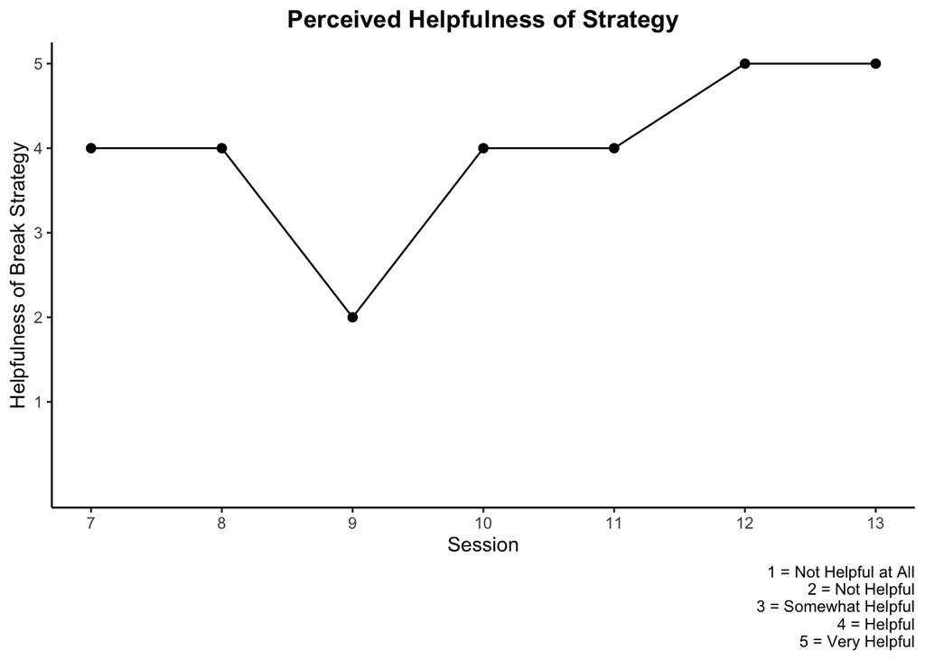

#### Frequency of Use of Reminders Strategy

Participant reported she only attended one class period prior to session 13 due to the start of the holiday break, which reduced her ability to adhere to all 12 reminders. She further clarified it was a reduced class period, so she only felt the need to adhere to 3 out of the 6 reminders per that class period to utilize the break strategy; however, she reported positive benefit of the reminders strategy.

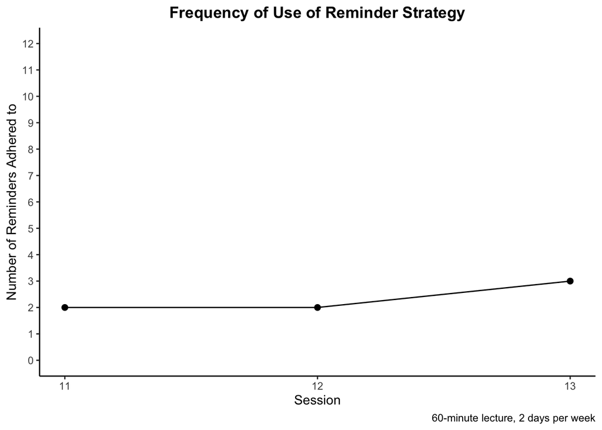

#### Perceived Helpfulness of Reminders Strategy

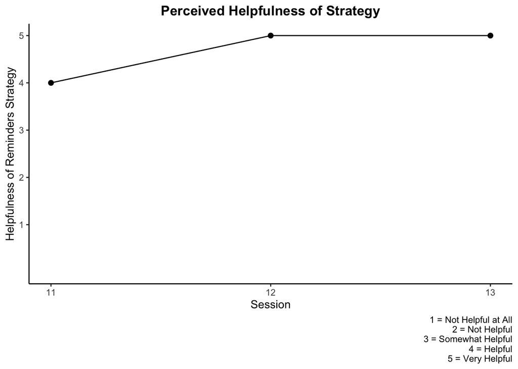

## Treatment Implementation Measurements

### TARF

The TARF is used to measure social validity.

| Question | Response |
| --- | --- |
| The clinician's teaching of the cognitive strategy was effective | Agree |
| I was motivated to use my strategy outside of therapy sessions | Agree |
| The duration of time to learn my cognitive strategy was longer than anticipated | Agree |
| I am confident I learned my cognitive strategy | Agree |
| Learning a cognitive strategy helped me reach my school and other goals | Strongly agree |
| I liked attending therapy sessions | Strongly agree |
| I experienced discomfort learning and implementing a cognitive strategy to address my school and other goals | Disagree |
| To what extent do you feel like you understand the concept and importance of cognitive strategy instruction? | NA |
| Anything else you would like to share with us? | NA |

### Treatment Compliance

Participant 1 rescheduled her tenth session two consecutive weeks, resulting in two total canceled/rescheduled sessions.